# R Notebook- PRACTICA 6

Ejercicio 1: datos del titanic y rpart

Se le proporciona un fichero de nombre “train.csv” que contiene 4 columnas con valores numéricos y categóricos. Las variables son:

- Sobrevivió, 0 ó 1, donde 0 es no sobrevive.

- Clase: los pasajeros tienen billete de 1º, 2º o 3º.

- Sexo: variable categórica con el género.

- Y finalmente edad.

Estos datos representan las variables de 500 pasajeros del crucero Titanic. El objetivo es crear un modelo de predicción de la supervivencia de los pasajeros. Para ello realice los siguientes pasos:

1. Cargue los datos en una variable de nombre train que será un dataframe con 4 variables o atributos y 500 observaciones (pasajeros) que vienen codificados en el fichero. Para ello:

train<-read.delim(“train.csv”, sep = “\t”, head = TRUE)

rownames(train) <- train$id

train$id <- NULL

Inspeccione el conjunto de entrenamiento (funciones head, str, dim).

```r
# PONER UNA NUEVA CELDA CTROL+ALT+I


train<-read.delim("train.csv", sep = "\t", head = TRUE)

#aqui poingo la colimna id como filas
rownames(train) <- train$id
#puede ser que quite la columna id
train$id <- NULL


#fijo la semilla antes de empezar--> se me generan siempre los mismos numero aletorios en esta sesion (para los algoritmos)
set.seed(1)

#VER TABLA
head(train)
```

|  | Survived | Pclass | Sex | Age |
| --- | --- | --- | --- | --- |
| 190 | 0 | 2 | male | 24 |
| 266 | 1 | 1 | female | 16 |
| 408 | 1 | 1 | male | 36 |
| 646 | 0 | 2 | male | 39 |
| 144 | 0 | 2 | male | 30 |
| 637 | 0 | 3 | female | 30 |

```r
str(train)
```

```
'data.frame':   500 obs. of  4 variables:
 $ Survived: int  0 1 1 0 0 0 0 0 1 1 ...
 $ Pclass  : int  2 1 1 2 2 3 3 3 3 2 ...
 $ Sex     : chr  "male" "female" "male" "male" ...
 $ Age     : num  24 16 36 39 30 30 21 35 36 5 ...
```

```r
dim(train) # 500 filas 4 variables
```

```
[1] 500   4
```

Cargue los siguientes paquetes para crear árboles de decisión.

3. La función para crear árboles de decisión que vamos a utilizar es rpart. Teclee en la consola help(“rpart”) y estudie como aplicarla. Utilice los parámetros:

o Formula, indicando que el objetivo a predecir es la supervivencia en función del resto de atributros.

o Indique el conjunto de entrenamiento.

o El parámetro method indique que va a realizar clasificación sobre variables categóricas o factor en R.

o Visualice el resultado usando la función plot.

```r
#install.packages("rattle")
library(rpart)
library(rattle)
library(RColorBrewer)
```

```r
#HAY QUE PONERLO DIRECTAMENTE EN LA CONSOLA
#help("rpart")
```

```r
#formula -> significa que predecimos la variable supervivencia a partir del resto

arbol_1 <- rpart(formula = Survived ~ . , data = train)

# si quisiera predecir en funcion de dos col pondria el nombre de las 2 en vez de
# del .
```

```r
arbol_1
```

```
n= 500

node), split, n, deviance, yval
      * denotes terminal node

 1) root 500 120.950000 0.4100000
   2) Sex=male 320  54.121880 0.2156250
     4) Age>=3.5 309  48.349510 0.1941748
       8) Pclass>=1.5 234  26.893160 0.1324786 *
       9) Pclass< 1.5 75  17.786670 0.3866667
        18) Age>=43 35   5.600000 0.2000000 *
        19) Age< 43 40   9.900000 0.5500000 *
     5) Age< 3.5 11   1.636364 0.8181818 *
   3) Sex=female 180  33.244440 0.7555556
     6) Pclass>=2.5 66  16.257580 0.4393939 *
     7) Pclass< 2.5 114   6.570175 0.9385965 *
```

```r
# parametro method -> NS MUY BIEN Q HACE

arbol_2 <- rpart(formula = Survived ~ ., data = train, method= "class")
```

[figure not shown]

```r
#rpart.plot(arbol_1) # no me funciona
fancyRpartPlot(arbol_1)
```

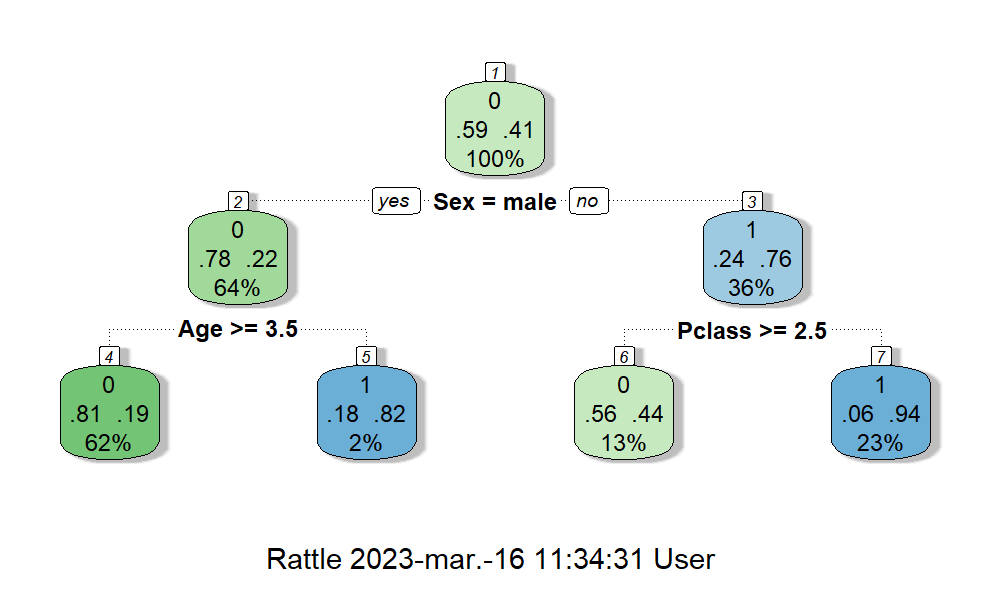

```r
fancyRpartPlot(arbol_2)
```

Analizamos el resultado. Indique cuál de las siguientes afirmaciones es correcta, (recuerda, 0 no sobrevive 1 vive) :

INTERPRETACION: NODO 1: CAEN EL 100% DE LOS INDIVIDUOS // 59% MUEREN y 41% VIVEN

NODO 2: CAEN EL 64% DE TODOS LOS INDIVIDUOS // 78% MUERE y 22% VIVEN –> si se podara predeciria que MUEREN –>0

NODO 5: CAEN EL 2% DE TODOS LOS IND // 18% mueren y 82% viven –> predice que viven

 El árbol predecirá que las pasajeras de la clase 3 no sobrevivirán, aunque está cerca.

VERDADERO -> 56% de probabilidades a que mueran

 La clase mayoritaria del nodo raíz es positiva, lo que denota supervivencia.

FALSO –> 59% de los individuos que caen al nodo raiz MUEREN

 El atributo que sigue al género es hombre es una variable categórica.

FALSO--> es numerica (pero esta discretizada)

4)Cargue el conjunto de datos de test del fichero con nombre “test.csv” de igual modo en el que se realizó la carga de los datos de entrenamiento. Realice la predicción con el conjunto de test para construir la matriz de confusión y calcular la accuracy del modelo, utilizando las funciones predict y table respectivamente.

```r
# PONER UNA NUEVA CELDA CTROL+ALT+I

test<-read.delim("test.csv", sep = "\t", head = TRUE)

#aqui poingo la colimna id como filas
rownames(test) <- test$id
#puede ser que quite la columna id
test$id <- NULL


#fijo la semilla antes de empezar--> se me generan siempre los mismos numero aletorios en esta sesion (para los algoritmos)
set.seed(1)

#VER TABLA
head(test)
```

|  | Survived | Pclass | Sex | Age |
| --- | --- | --- | --- | --- |
| 555 | 0 | 3 | male | 42.0 |
| 147 | 1 | 2 | male | 1.0 |
| 140 | 0 | 3 | male | 21.0 |
| 652 | 0 | 3 | male | 30.5 |
| 290 | 0 | 2 | male | 29.0 |
| 412 | 1 | 2 | female | 34.0 |

```r
str(test)
```

```
'data.frame':   214 obs. of  4 variables:
 $ Survived: int  0 1 0 0 0 1 1 1 1 0 ...
 $ Pclass  : int  3 2 3 3 2 2 3 1 1 1 ...
 $ Sex     : chr  "male" "male" "male" "male" ...
 $ Age     : num  42 1 21 30.5 29 34 21 32 44 37 ...
```

```r
dim(test) # 500 filas 4 variables
```

```
[1] 214   4
```

```r
pred <- predict(arbol_2, test, type = 'class')

conf <- table (test$Survived, pred)

#calcula el acccuracy
acc<- sum(diag(conf)) / sum(conf)
print(acc)
```

```
[1] 0.7990654
```

5. Copie el siguiente código

¿Qué observa? El modelo resultante funciona bien si calculamos su accuracy pero es difícil de interpretar. Para arreglar esta situación pode el árbol con la función prune y vuelva a dibujarlo.

Se observa que el modelo se esta sobreajustando a los datos

[figure not shown]

```r
set.seed(1) # no hace falta otra vez
tree <- rpart(Survived ~., train, method="class", control=rpart.control(cp=0.00001)) # el metodo control implica mejorar el arbol (tunearlo), mejora el rendimiento
fancyRpartPlot(tree)
```

```r
# COPIAR DE LA PROFESORA LO VA A SUBIR RESUELTO

#pruebo el rendimiento del modelo sobreajustado

# habria que podarlo
```

EJERCICIO 2

Ejercicio 2: datos del titanic y evaluación mediante curva ROC

Vamos a realizar una análisis ROC y para ello siga los siguientes pasos:

1. Cargue la librería ROCR. Llame a la función prediction pasando como argumentos las probabilidades y la columna del atributo clase. El resultado de esta función, juntos con “tpr” y “fpr” utilícelo como argumentos de entradas de la función performance. Finalmente llame a la función plot dando como entrada el resultado de la función anterior.